# Information Imbalance Tutorial

Aiden Price

2024-01-30

To see all functions which you can call within this class, please refer to: https://dadapy.readthedocs.io/en/latest/metric_comparisons.html

```r
library(ggplot2)   # For plotting.
library(MASS)      # For the multivariate normal distribution.
```

## 3D Gaussian with Small Variance Along $z$

In this section we define a simple dataset sampled from a 3D Gaussian distribution with a small variance along the $z$ axis.

### Included methods:

- Prediction of the full feature space vs. specified subsets of features: return_inf_imb_full_selected_coords

```r
# Create a sample data set
N <- 1000

# Identity for covariance.
cov <- diag(3)

# Reduce variance along z.
cov[3, 3] <- 0.01^2

# Constant mean.
mean <- rep(0, 3)

# Generate the sample data set.
X <- mvrnorm(n = N, mu = mean, Sigma = cov)

# Convert the matrix X to a data frame.
X_df <- as.data.frame(X)

# Use familiar dimension names.
names(X_df) <- c("x", "y", "z")

# Sample of resulting data frame.
head(X_df)
```

```
##             x           y            z
## 1  0.41896126  0.69336013  0.015324605
## 2  0.84349577  0.65261621  0.007795394
## 3  1.35785509 -0.46722248 -0.022645388
## 4  0.02619858  0.48932572 -0.013927339
## 5 -1.00184308  0.06068931  0.011117572
## 6  0.36460345  2.94067074  0.012779657
```

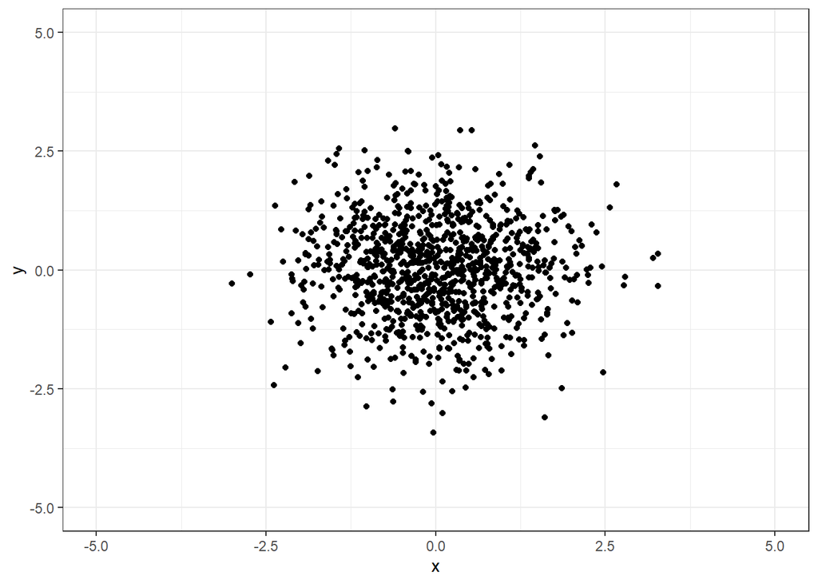

```r
# Create the first scatter plot (x vs y)
ggplot(X_df, aes(x = x, y = y)) +
  geom_point() +
  xlim(-5, 5) +
  ylim(-5, 5) +
  xlab("x") +
  ylab("y") +
  theme_bw()
```

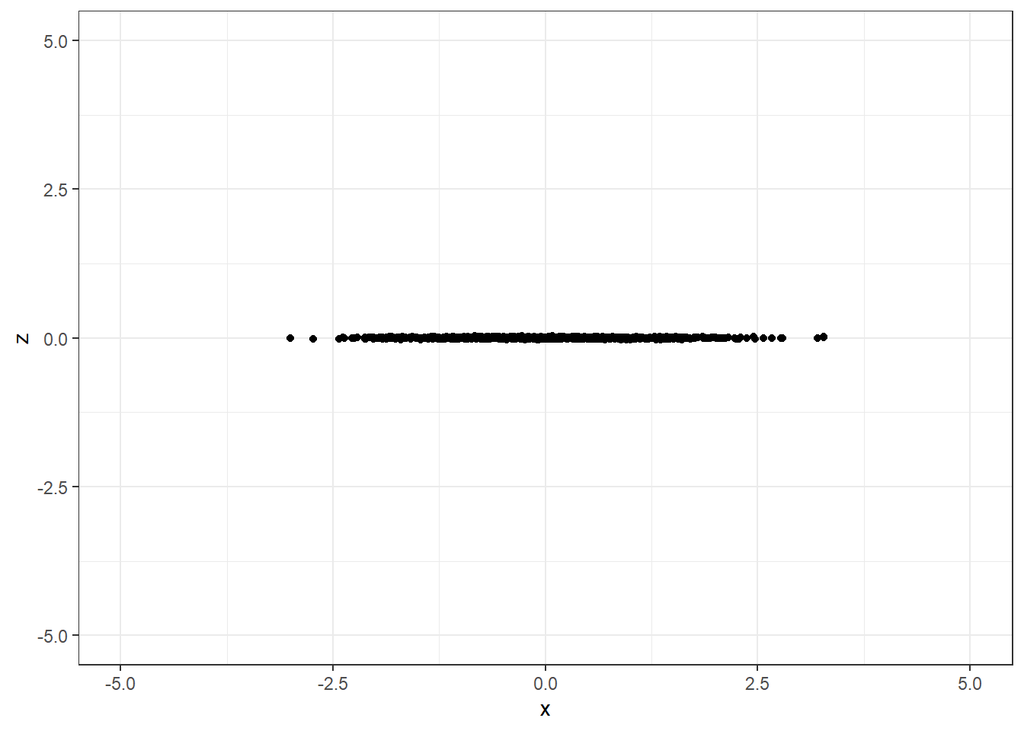

```r
# Create the second scatter plot (x vs z)
ggplot(X_df, aes(x = x, y = z)) +
  geom_point() +
  xlim(-5, 5) +
  ylim(-5, 5) +
  xlab("x") +
  ylab("z") +
  theme_bw()
```

```r
# Define an instance of the "MetricComparisons" class.
d <- MetricComparisons(coordinates = X, maxk = N - 1)
```

The parameter $maxk$ defines the order of the last neighbor identified in space $\mathbf{B}$, when the information imbalance $\Delta(\mathbf{A}\rightarrow\mathbf{B})$ is computed: if a conditional rank in $\mathbf{B}$ is not within $maxk$, its value is set randomly to an integer between $maxk+1$ and $N-1$. The information imbalance is computed with no approximations when $maxk = N-1$; however, decreasing this parameter can significantly speed up the computation for large data sets. The default value of $maxk$ is 100.

```r
# List of the coordinate names.
labels <- c("x", "y", "z")

# List of the the subsets of coordinates for which the imbalance should be computed.
coord_list <- list(c(1), c(2), c(3), c(1,2), c(1,3), c(2,3))

# Compute the information imbalances from the full 3D space to the spaces in "coord_list" and viceversa.
imbalances <- return_inf_imb_full_selected_coords(d, coord_list, k = 1)
```

The parameter $k$ defines how many neighbors of each point are considered in space $\mathbf{A}$ when we compute the information imbalance $\Delta(\mathbf{A}\rightarrow\mathbf{B})$, and its default value is 1.

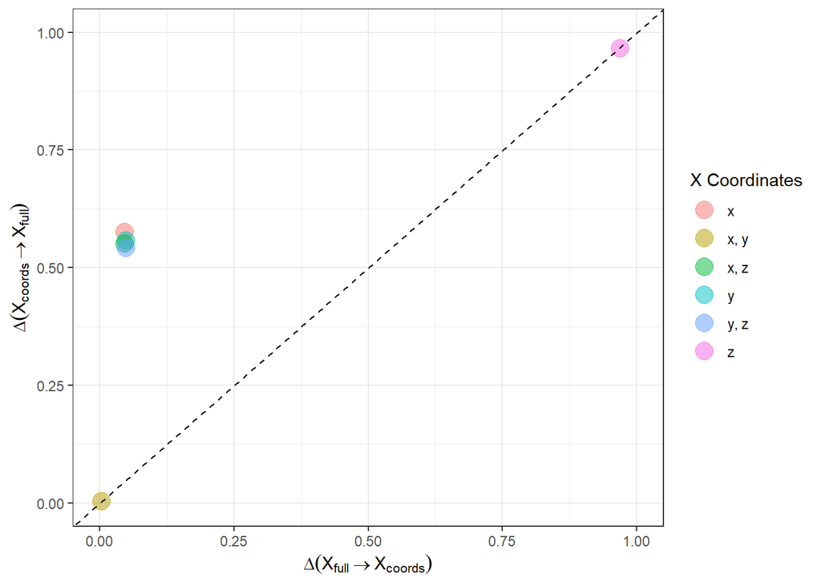

```r
# Plot information imbalance plane.
plot_inf_imb_plane(imbalances, coord_list, labels)
```

## 4D Isotropic Gaussian

In this example we explore the possibility of having a symmetrical yet partial sharing of information between two spaces. We will take the case of a data set sampled from a 4D isotropic Gaussian.

### Included methods:

- Prediction of two feature subsets vs. each other: “return_inf_imb_two_selected_coords”

```r
# sample the data set
N <- 2000

X <- matrix(rnorm(N * 4), ncol = 4)
```

```r
# define an instance of the MetricComparisons class
d <- MetricComparisons(coordinates = X, maxk = N - 1, metric = "euclidean")
```

```r
# compute the imbalance between the [x, y] space and the [y, z] space
imb_1common <- return_inf_imb_two_selected_coords(d, c(1, 2), c(2, 3))

# compute the imbalance between the [x, y, z] space and the [y, z, w] space
imb_2common <- return_inf_imb_two_selected_coords(d, c(1, 2, 3), c(2, 3, 4))

print(imb_1common)
```

```
## [[1]]
## [1] 0.5681505
##
## [[2]]
## [1] 0.5462575
```

```r
print(imb_2common)
```

```
## [[1]]
## [1] 0.3344555
##
## [[2]]
## [1] 0.328557
```

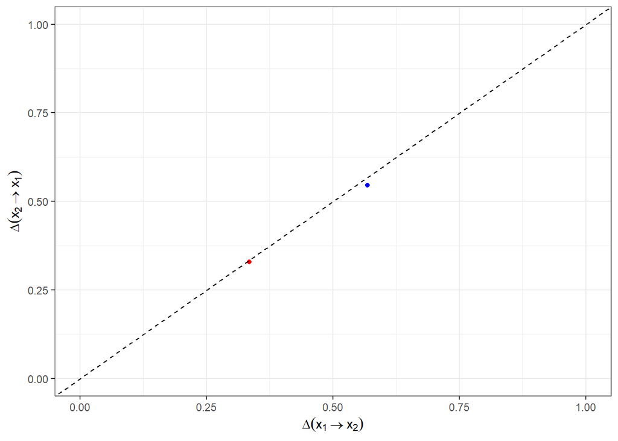

```r
df <- data.frame(
  imb_1_x = imb_1common[[1]],
  imb_1_y = imb_1common[[2]],
  imb_2_x = imb_2common[[1]],
  imb_2_y = imb_2common[[2]]
)

# Create the plot
ggplot() +
  geom_point(data = df, aes(x = imb_1_x, y = imb_1_y), color = "blue") +
  geom_point(data = df, aes(x = imb_2_x, y = imb_2_y), color = "red") +
  geom_abline(intercept = 0, slope = 1, linetype = "dashed") +
  xlab(expression(Delta(x[1] %->% x[2]))) +
  ylab(expression(Delta(x[2] %->% x[1]))) +
  theme_bw() +
  xlim(0,1) +
  ylim(0,1)
```